# Chapter 5 - CCA: exercises

Author

Prof. Richard Wilkinson

## Question 1

A sales company surveyed $50$ of its employees in order to determine the factors that influence sales performance. Two collections of variables were measured. The first set related to sales performance

- Sales Growth
- Sales Profitability
- New Account Sales

The second set of variables are test scores measuring intelligence:

- Creativity
- Mechanical Reasoning
- Abstract Reasoning
- Mathematics

You can download the data set `sales.csv` from Moodle. The following analysis is carried out in R.

```r
dat=read.csv(file='sales2.csv', sep=',',header=TRUE)
X = dat |> dplyr::select('growth', 'profit', 'new')
Y = dat |> dplyr::select(-'growth', -'profit', -'new')

library(CCA)
cc.out <- cc(X,Y)
print(cc.out$cor)
```

```
[1] 0.9944827 0.8781065 0.3836057
```

```r
print(cc.out$xcoef)
```

```
              [,1]       [,2]       [,3]
growth -0.06237788 -0.1740703  0.3771529
profit -0.02092564  0.2421641 -0.1035150
new    -0.07825817 -0.2382940 -0.3834151
```

```r
print(cc.out$ycoef)
```

```
              [,1]        [,2]        [,3]
create -0.06974814 -0.19239132 -0.24655659
mech   -0.03073830  0.20157438  0.14189528
abs    -0.08956418 -0.49576326  0.28022405
math   -0.06282997  0.06831607 -0.01133259
```

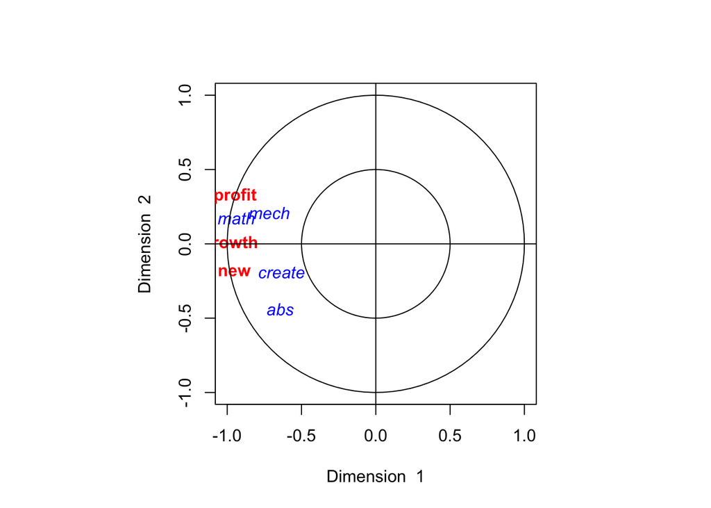

```r
plt.cc(cc.out,var.label = TRUE,
       type='v')
```

The following gives the correlation between the original variables and the transformed variables

```r
print(cc.out$scores$corr.X.xscores)
```

```
             [,1]          [,2]         [,3]
growth -0.9798776  0.0006477883  0.199598477
profit -0.9464085  0.3228847489 -0.007504408
new    -0.9518620 -0.1863009724 -0.243414776
```

```r
print(cc.out$scores$corr.Y.yscores)
```

```
             [,1]       [,2]        [,3]
create -0.6383313 -0.2156981 -0.65140953
mech   -0.7211626  0.2375644  0.06773775
abs    -0.6472493 -0.5013329  0.57422365
math   -0.9440859  0.1975329  0.09422619
```

```r
print(cc.out$scores$corr.X.yscores)
```

```
             [,1]          [,2]         [,3]
growth -0.9744713  0.0005688272  0.076567107
profit -0.9411869  0.2835272081 -0.002878734
new    -0.9466102 -0.1635921013 -0.093375287
```

```r
print(cc.out$scores$corr.Y.xscores)
```

```
             [,1]       [,2]        [,3]
create -0.6348095 -0.1894059 -0.24988439
mech   -0.7171837  0.2086069  0.02598458
abs    -0.6436782 -0.4402237  0.22027544
math   -0.9388771  0.1734549  0.03614570
```

- Describe the first pair of canonical variables, give their correlation, and provide an interpretation.
- Describe the second pair of canonical variables, and provide an interpretation.

**Solution**

- The first pair of canonical variables is
  $$\eta_1= -0.062 \times \mbox{Growth} -0.0209 \times \mbox{Profit}-0.078 \times \mbox{new}$$
  and
  $$\psi_1 = -0.0697 \times \mbox{create}-0.03 \times \mbox{mech}-0.090 \times \mbox{abs}-0.063 \times \mbox{math}$$

The correlation between $\eta_1$ (the transformed scales variable) and $\psi_1$ (the transformed test scores variable) is very high at 0.994.

To interpret the variables, note that
$${\mathbb{C}\operatorname{or}}(\eta_1, \mbox{growth}) = -0.98, \quad {\mathbb{C}\operatorname{or}}(\eta_1, \mbox{profit}) = -0.95,\quad {\mathbb{C}\operatorname{or}}(\eta_1, \mbox{new}) = -0.95$$

These correlations are all uniformly large. Therefore, you can think of this canonical variate as an overall measure of Sales Performance.

Because the first canonical correlation is very high (0.99), we can see that the correlations between each set of variables and the opposite group of canonical variates is also high. So

$${\mathbb{C}\operatorname{or}}(\eta_1, \mbox{create}) = -0.63, \quad {\mathbb{C}\operatorname{or}}(\eta_1, \mbox{mech}) = -0.72,\quad {\mathbb{C}\operatorname{or}}(\eta_1, \mbox{abs}) = -0.64,\quad {\mathbb{C}\operatorname{or}}(\eta_1, \mbox{math}) = -0.94$$

$${\mathbb{C}\operatorname{or}}(\psi_1, \mbox{growth}) = -0.97, \quad {\mathbb{C}\operatorname{or}}(\psi_1, \mbox{profit}) = -0.94,\quad {\mathbb{C}\operatorname{or}}(\psi_1, \mbox{new}) = -0.95$$
For the second set of canonical variables, note that the correlation between the original variables and the transformed variables is low.

$${\mathbb{C}\operatorname{or}}(\eta_2, \mbox{growth}) =0.0006, \quad {\mathbb{C}\operatorname{or}}(\eta_2, \mbox{profit}) = 0.322,\quad {\mathbb{C}\operatorname{or}}(\eta_2, \mbox{new}) = -0.186$$

$${\mathbb{C}\operatorname{or}}(\psi_2, \mbox{create}) = -0.22, \quad {\mathbb{C}\operatorname{or}}(\psi_2, \mbox{mech}) = 0.24,\quad {\mathbb{C}\operatorname{or}}(\psi_2, \mbox{abs}) = -0.50,\quad {\mathbb{C}\operatorname{or}}(\psi_2, \mbox{math}) = 0.20$$
So it there isn’t really a meaningful interpretation that can be given.

## Question 2

Attempt exam question 1 part (b) from the 2017-18 exam paper:

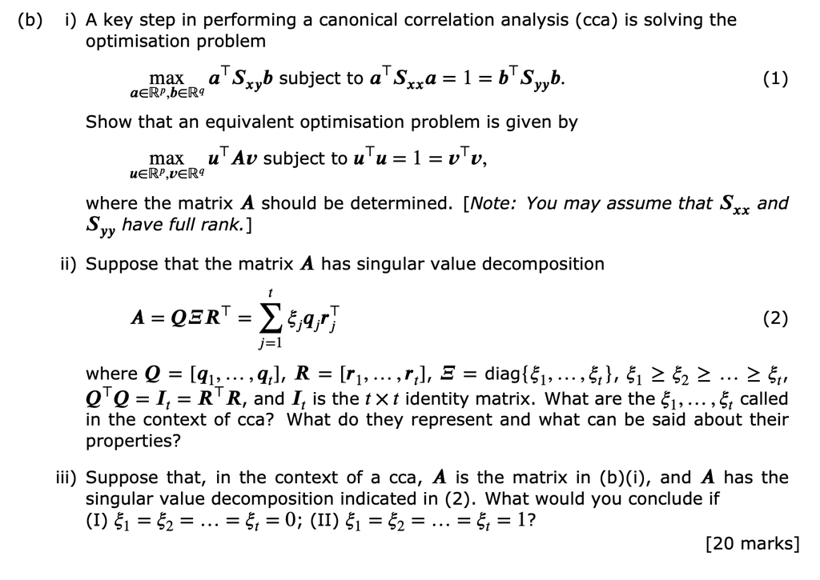

**Solution**

This is all bookwork material from the notes.

1. Put $\mathbf u=\mathbf S_{xx}^{1/2}\mathbf a$ and $\mathbf v=\mathbf S_{yy}^{1/2}\mathbf b$. Then $\mathbf a=\mathbf S_{xx}^{-1/2}\mathbf u$ and $\mathbf b=\mathbf S_{yy}^{-1/2}\mathbf v$. This transforms eq. (1) into

$$\max_{\mathbf u, \mathbf v} \mathbf u^\top \mathbf S_{xx}^{-1/2}\mathbf S_{xy}\mathbf S_{yy}^{-1/2}\mathbf v\mbox{ subject to } \mathbf u^\top\mathbf u=\mathbf v^\top\mathbf v=1$$
i.e., we have $\mathbf A=\mathbf S_{xx}^{-1/2}\mathbf S_{xy}\mathbf S_{yy}^{-1/2}$.

2. $\xi_1, \xi_2, \ldots$ are the canonical correlations. $\xi_1$ is the largest correlation possible between any linear combination of the x-variables and any linear combination of the y-variables. Subsequent $\xi_i$ are the largest correlation between additional linear combinations, subject to them being uncorrelated with earlier variables. We have that $0\leq \xi_i\leq 1$ with $\xi_1\geq \xi_2\geq \ldots$.
3. If $\xi_i=0$ for all $i$, we would conclude that all possible linear correlations of $\mathbf x$ and $\mathbf y$ are uncorrelated. We can see that this only occurs in the SVD when $\mathbf S_{xy}$ is the $p \times q$ matrix of zeros.

If $\xi_i=1$ for all $i$, this indicates perfect correlation between the $\mathbf x$-variables and the $\mathbf y$-variables. In the next question, we will see that this happens if $\mathbf y=\mathbf T\mathbf x$ for some orthogonal matrix $\mathbf T$.

## Question 3

Suppose that $\mathbf z= (\mathbf x^\top \mathbf y^\top)^\top$ is a random vector, where both $\mathbf x$ and $\mathbf y$ are sub-vectors of dimension $p$, so that $\mathbf z$ is $(2p)\times 1$. Define
$${\mathbb{V}\operatorname{ar}}(\mathbf z)=\boldsymbol{\Sigma}_{\mathbf z\mathbf z}=\begin{pmatrix} \boldsymbol{\Sigma}_{\mathbf x\mathbf x} & \boldsymbol{\Sigma}_{\mathbf x\mathbf y}\\\boldsymbol{\Sigma}_{\mathbf y\mathbf x} & \boldsymbol{\Sigma}_{\mathbf y\mathbf y} \end{pmatrix}.$$

1. Suppose that $\mathbf y= \mathbf T\mathbf x$ where $\mathbf T$ is a fixed matrix. Find $\boldsymbol{\Sigma}_{\mathbf x\mathbf y}$ and $\boldsymbol{\Sigma}_{\mathbf y\mathbf y}$ in terms of $\boldsymbol{\Sigma}_{\mathbf x\mathbf x}$ and $\mathbf T$.

**Solution**

We have
$$\boldsymbol{\Sigma}_{\mathbf x\mathbf y}=\text{Cov}(\mathbf x, \mathbf y) =\text{Cov}(\mathbf x, \mathbf T\mathbf x)=\text{Cov}(\mathbf x, \mathbf x)\mathbf T^\top
=\boldsymbol{\Sigma}_{\mathbf x\mathbf x}\mathbf T^\top,$$
and
$$\boldsymbol{\Sigma}_{\mathbf y\mathbf y}=\text{Var}(\mathbf T\mathbf x)=\mathbf T\boldsymbol{\Sigma}_{\mathbf x\mathbf x}\mathbf T^\top.$$

2. Assuming now that $\mathbf T$ is an orthogonal matrix and $\boldsymbol{\Sigma}_{\mathbf x\mathbf x}$ is of full rank, determine the singular values of the matrix $\mathbf Q=\boldsymbol{\Sigma}_{\mathbf x\mathbf x}^{-1/2}\boldsymbol{\Sigma}_ {\mathbf x\mathbf y}\boldsymbol{\Sigma}_{\mathbf y\mathbf y}^{-1/2}$, and hence write down the canonical correlation coefficients.

**Solution**

Write the spectral decomposition of $\boldsymbol{\Sigma}_{\mathbf x\mathbf x}$ as
$$\boldsymbol{\Sigma}_{\mathbf x\mathbf x}=\mathbf U\boldsymbol \Lambda\mathbf U^\top.$$
Then, since $\mathbf T$ is an orthogonal matrix, the spectral decomposition of $\boldsymbol{\Sigma}_{\mathbf y\mathbf y}$ is given by
$$\boldsymbol{\Sigma}_{\mathbf y\mathbf y}=\mathbf T\mathbf U\boldsymbol \Lambda\mathbf U^\top \mathbf T^\top=(\mathbf T\mathbf U)\boldsymbol \Lambda(\mathbf T\mathbf U)^\top,$$
because $\mathbf U$ and $\mathbf T$, and hence $\mathbf T\mathbf U$, are orthogonal matrices; so the eigenvalues of $\boldsymbol{\Sigma}_{\mathbf y\mathbf y}$ are the same as those of $\boldsymbol{\Sigma}_{\mathbf x\mathbf x}$, and the corresponding matrix of unit eigenvectors of $\boldsymbol{\Sigma}_{\mathbf y\mathbf y}$ is given by $\mathbf T\mathbf U$. Therefore the inverse matrix square roots of $\boldsymbol{\Sigma}_{\mathbf x\mathbf x}$ and $\boldsymbol{\Sigma}_{\mathbf y\mathbf y}$ are, respectively,
$$\boldsymbol{\Sigma}_{\mathbf x\mathbf x}^{-1/2}=\mathbf U\boldsymbol \Lambda^{-1/2} \mathbf U^\top \quad \hbox{and} \quad \boldsymbol{\Sigma}_{\mathbf y\mathbf y}^{-1/2}=\mathbf T\mathbf U\boldsymbol \Lambda^{-1/2} (\mathbf T\mathbf U)^\top.$$
Consequently, assuming that all the eigenvalues of $\boldsymbol{\Sigma}_{\mathbf x\mathbf x}$ are strictly positive,
$$\begin{align*}
\mathbf Q& =\boldsymbol{\Sigma}_{\mathbf x\mathbf x}^{-1/2}\boldsymbol{\Sigma}_{\mathbf x\mathbf y} \boldsymbol{\Sigma}_{\mathbf y\mathbf y}^{-1/2}\\
&=\mathbf U\boldsymbol \Lambda^{-1/2}\mathbf U^\top \boldsymbol{\Sigma}_{\mathbf x\mathbf x}\mathbf T^\top \mathbf T\mathbf U\boldsymbol \Lambda^{-1/2} \mathbf U^\top \mathbf T^\top\\
&=\mathbf U\boldsymbol \Lambda^{-1/2}\mathbf U^\top \mathbf U\boldsymbol \Lambda\mathbf U^\top \mathbf T^\top \mathbf T\mathbf U\boldsymbol \Lambda^{-1/2} \mathbf U^\top \mathbf T^\top\\
&=\mathbf U\boldsymbol \Lambda^{-1/2}\boldsymbol \Lambda\boldsymbol \Lambda^{-1/2}\mathbf U^\top \mathbf T^\top\\
&=\mathbf T^\top.
\end{align*}$$
If we rewrite this as
$$\mathbf Q=\mathbf T^\top= \mathbf I_p \mathbf I_p \mathbf T^\top,$$
we can see this is already in SVD form. Here, the $\mathbf I_p$ on the left is the matrix of left singular vectors, the $\mathbf I_p$ in the middle is the diagonal matrix of singular values, and $\mathbf T$ is the matrix of right singular vectors. Or we can rewrite it as

$$\mathbf Q=\mathbf I_p \mathbf I_p \mathbf T^\top = \sum_{j=1}^p \mathbf e_j {\mathbf t}_j^\top,$$
where $\mathbf e_j$ is the $j$th column of $\mathbf I_p$ and ${\mathbf t}_j$ is the $j$th column of $\mathbf T$. So in this case the canonical correlation coefficients are all equal to $1$, i.e. the set of $x$-variables and the set of $y$-variables are, in this sense, perfectly correlated.

3. Suppose now that $\mathbf T$ is non-singular but not orthogonal. Comment on whether the answer to part (b) changes.

**Solution**

Yes, the answer changes if $\mathbf T$ is not an orthogonal matrix because then the eigenvalues of $\boldsymbol{\Sigma}_{\mathbf y\mathbf y}$ will differ from those of $\boldsymbol{\Sigma}_{\mathbf x\mathbf x}$ and the two sets of variables will not be perfectly correlated, as happens in part (b).

## Question 4

We will now prove Proposition 5.3 by induction. The case for $k=1$ was proved in Section 5.1 in Proposition 3.9. Assume the result is true for $k$. Consider the objective
$$\mathcal{L} = \mathbf a^\top \mathbf Q\mathbf b+ \sum_{i=1}^k \gamma_i\mathbf a^\top \mathbf a_i + \sum_{i=1}^k \mu_i\mathbf b^\top \mathbf b_i + \frac{\lambda_1}{2}(1-\mathbf a^\top\mathbf a)+ \frac{\lambda_2}{2}(1-\mathbf b^\top\mathbf b)$$
where $\lambda_i, \mu_i, \gamma_i$ are Lagrangian multipliers.

1. By differentiating with respect to $\mathbf a$ and $\mathbf b$ and setting the derivative to zero show that

$$\mathbf Q\mathbf b+ \sum\gamma_i \mathbf a_i - \lambda_1 \mathbf a= 0
\tag{1}$$

$$\mathbf Q^\top\mathbf a+ \sum\mu_i \mathbf b_i - \lambda_2 \mathbf b= 0. \tag{2}$$

**Solution**

$$\frac{d\mathcal{L}}{d\mathbf a} = \mathbf Q\mathbf b+\sum_{i=1}^k \gamma_i\mathbf a_i -\lambda_1\mathbf a$$
$$\frac{d\mathcal{L}}{d\mathbf b} = \mathbf Q^\top \mathbf a+\sum_{i=1}^k \mu_i\mathbf b_i -\lambda_2\mathbf b$$
Setting these equal to zero (as the derivatives will be zero at the maximum) gives the required equations.

2. By left multiplying the equations above by $\mathbf a^\top$ and $\mathbf b^\top$ respectively show that
   $$\lambda_1=\lambda_2 = \mathbf a^\top \mathbf Q\mathbf b.$$

**Solution**

$$0=\mathbf a^\top(\mathbf Q\mathbf b+\sum_{i=1}^k \gamma_i\mathbf a_i -\lambda_1\mathbf a) = \mathbf a^\top\mathbf Q\mathbf b+\sum_{i=1}^k \gamma_i\mathbf a^\top\mathbf a_i -\lambda_1\mathbf a^\top\mathbf a= \mathbf a^\top\mathbf Q\mathbf b-\lambda_1$$
as $\mathbf a^\top\mathbf a=1$ and $\mathbf a^\top \mathbf a_i=0$. Thus $\lambda_1 = \mathbf a^\top \mathbf Q\mathbf b$ as required. Similarly for $\lambda_2$.

3. By left multiplying (Equation 1) by $\mathbf a_i^\top$ show that $\gamma_i=0$ for $i=1, \ldots, k$. Show similarly that $\mu_i =0$ for $i=1, \ldots, k$.

**Solution**

$$0=\mathbf a_i^\top(\mathbf Q\mathbf b+\sum_{i=1}^k \gamma_i\mathbf a_i -\lambda_1\mathbf a) = \mathbf a_i^\top\mathbf Q\mathbf b+\sum_{i=j}^k \gamma_j\mathbf a_i^\top\mathbf a_j -\lambda_1\mathbf a_i^\top\mathbf a= \mathbf a_i^\top\mathbf Q\mathbf b+\gamma_i$$
But $\mathbf Q=\sum_{j} \sigma_j \mathbf u_j \mathbf v_j^\top$ and $\mathbf a_i = \mathbf u_i$ and thus
$$\mathbf a_i^\top\mathbf Q\mathbf b= \sigma_i \mathbf v_i^\top\mathbf b= \sigma_i\mathbf b_i^\top \mathbf b= 0$$
as $\mathbf v_i=\mathbf b_i$. Thus $\gamma_i=0$. Similarly $\mu_i=0$.

4. Finally, by copying the proof of Proposition 3.9, prove Proposition 5.3.

**Solution**

We have shown $\lambda_1\mathbf a= \mathbf Q\mathbf b$ and $\lambda_1\mathbf b= \mathbf Q^\top \mathbf a$. Substituting one equation into the other, gives
$$\mathbf Q\mathbf Q^\top \mathbf a= \lambda_1^2\mathbf a$$
So $\mathbf a$ is an eigenvalue of $\mathbf Q\mathbf Q^\top$ and so $\mathbf a=\mathbf u_i$ for some $i$, and $\lambda_1=\mathbf a^\top\mathbf Q\mathbf b=\sigma_i$. We know we can’t pick $i=1, \ldots, k$ by the orthogonality constraints, and so we pick the next largest possible singular value, and let $\mathbf a=\mathbf u_{k+1}, \mathbf b=\mathbf b_{k+1}$ and then
$$\mathbf u_{k+1}^\top \mathbf Q\mathbf b_{k+1} =\sigma_{k+1}.$$

Then by induction we have proven the result.

## Question 5

Show the mean of the cc variables $\eta_k$ and $\psi_k$ is zero. Prove Proposition 5.4 giving the variance of covariance the canonical correlation variables.

**Solution**

$$\eta_k=\mathbf a_k^\top (\mathbf x- \bar{\mathbf x})$$
Thus
$${\mathbb{E}}\eta_k={\mathbb{E}}(\mathbf a_k^\top (\mathbf x- \bar{\mathbf x})) = \mathbf a_k^\top ({\mathbb{E}}\mathbf x- \bar{\mathbf x})=0$$
as required. Similarly for $\psi_k$.

$$\begin{align*}
{\mathbb{C}\operatorname{ov}}(\eta_j, \eta_k) &= {\mathbb{C}\operatorname{ov}}(\mathbf a_j^\top(\mathbf x-\bar{\mathbf x}), \mathbf a_k^\top(\mathbf x-\bar{\mathbf x}))\\
&=\mathbf a_j^\top \mathbf S_{xx}\mathbf a_k\\
&=\mathbf u_j^\top \mathbf S_{xx}^{-1/2}\mathbf S_{xx}\mathbf S_{xx}^{-1/2}\mathbf u_k\\
&=\mathbf u_j^\top \mathbf u_k\\
&=\begin{cases}1\mbox{ if } j=k\\
0 \mbox{ otherwise.}
\end{cases}
\end{align*}$$
Similarly for ${\mathbb{C}\operatorname{ov}}(\psi_j, \psi_k)$.

$$\begin{align*}
{\mathbb{C}\operatorname{ov}}(\eta_j, \psi_k) &= {\mathbb{C}\operatorname{ov}}(\mathbf a_j^\top(\mathbf x-\bar{\mathbf x}), \mathbf b_k^\top(\mathbf y-\bar{\mathbf y}))\\
&=\mathbf a_j^\top \mathbf S_{xy}\mathbf b_k\\
&=\mathbf u_j^\top \mathbf S_{xx}^{-1/2}\mathbf S_{xy}\mathbf S_{yy}^{-1/2}\mathbf v_k\\
&=\mathbf u_j^\top \mathbf Q\mathbf v_k\\
&=\mathbf u_j^\top \left(\sum_i \sigma_i \mathbf u_i \mathbf v_i^\top\right)\mathbf v_k\\
&=\begin{cases}\sigma_j\mbox{ if } j=k\\
0 \mbox{ otherwise.}
\end{cases}
\end{align*}$$

## Question 6

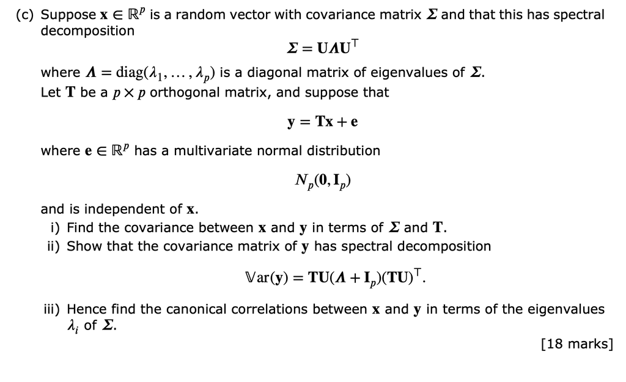

**Solution**

Note that this question is essentially the same as Q3.

1. $${\mathbb{C}\operatorname{ov}}(\mathbf x, \mathbf y) =
   {\mathbb{C}\operatorname{ov}}(\mathbf x, \mathbf T\mathbf x+\mathbf e) = \boldsymbol{\Sigma}\mathbf T^\top$$

or $\mathbf T\boldsymbol{\Sigma}$.

2. $$\begin{align*}
   {\mathbb{V}\operatorname{ar}}(\mathbf y) &= {\mathbb{V}\operatorname{ar}}(\mathbf T\mathbf x+\mathbf e)\\
   &= {\mathbb{V}\operatorname{ar}}(\mathbf T\mathbf x) + {\mathbb{V}\operatorname{ar}}(\mathbf e)\quad \mbox{ as } {\mathbb{C}\operatorname{ov}}(\mathbf T\mathbf x, \mathbf e)=0\\
   &=\mathbf T\boldsymbol{\Sigma}\mathbf T^\top +\mathbf I\\
   &=\mathbf T\mathbf U(\boldsymbol \Lambda+\mathbf I) (\mathbf T\mathbf U)^\top
   \end{align*}$$
3. The canonical correlations are the singular values of
   $$\begin{align*}
   \mathbf Q&= \boldsymbol{\Sigma}_{xx}^{-1/2}\boldsymbol{\Sigma}_{xy} \boldsymbol{\Sigma}_{yy}^{-1/2}\\
   &= (\mathbf U\boldsymbol \Lambda^{-1/2} \mathbf U^\top) (\mathbf U\boldsymbol \Lambda\mathbf U^\top \mathbf T^\top)(\mathbf T\mathbf U(\boldsymbol \Lambda+\mathbf I)^{-1/2} (\mathbf T\mathbf U)^\top)\\
   &= \mathbf U\boldsymbol \Lambda^{1/2}(\boldsymbol \Lambda+\mathbf I)^{-1/2} \mathbf T\mathbf U
   \end{align*}$$
   This is in SVD format as $\mathbf T\mathbf U$ is orthogonal, and $\boldsymbol \Lambda^{1/2}(\boldsymbol \Lambda+\mathbf I)^{-1/2}$ is diagonal, and so we can see that the canonical correlations are
   $$\frac{\sqrt{\lambda_i}}{\sqrt{\lambda_i+1}}.$$

## Question 7

The `mtcars` dataset in R contains data on 32 cars from the 1970s. We will split the data into two datasets. Let $\mathbf X$ be the matrix that contains variables pertaining to car characteristics:

1. cyl Number of cylinders
2. disp Displacement (cu.in.)
3. hp Gross horsepower
4. drat Rear axle ratio
5. wt Weight (1000 lbs)

and let $\mathbf Y$ be the matrix containing variables pertaining to car performance:

1. mpg Miles/(US) gallon
2. qsec 1/4 mile time

```r
X <- mtcars |> dplyr::select(cyl, disp, hp, drat, wt)
Y <- mtcars |> dplyr::select(mpg, qsec)
```

We can then do CCA on these two datasets

```r
library(CCA)
cc.out<-cc(X,Y)
print(cc.out$cor)
```

```
[1] 0.9270377 0.8307044
```

```r
print(cc.out$xcoef)
```

```
             [,1]         [,2]
cyl  -0.277988315  0.373120734
disp  0.001628855  0.003177998
hp   -0.005964078  0.007770195
drat  0.015934959  0.791032730
wt   -0.388097090 -1.423595709
```

```r
print(cc.out$ycoef)
```

```
          [,1]       [,2]
mpg  0.1451984  0.1109009
qsec 0.1346424 -0.6013371
```

```r
print(cc.out$scores$corr.X.xscores)
```

```
           [,1]        [,2]
cyl  -0.9578700  0.07914027
disp -0.9126296 -0.12094085
hp   -0.9164944  0.29160643
drat  0.6666822  0.43010103
wt   -0.8643963 -0.47212540
```

```r
print(cc.out$scores$corr.Y.xscores)
```

```
          [,1]       [,2]
mpg  0.9046387  0.1815048
qsec 0.5627028 -0.6601685
```

```r
print(cc.out$scores$corr.X.yscores)
```

```
           [,1]        [,2]
cyl  -0.8879817  0.06574217
disp -0.8460421 -0.10046609
hp   -0.8496249  0.24223874
drat  0.6180395  0.35728682
wt   -0.8013280 -0.39219665
```

```r
print(cc.out$scores$corr.Y.yscores)
```

```
          [,1]       [,2]
mpg  0.9758380  0.2184951
qsec 0.6069902 -0.7947093
```

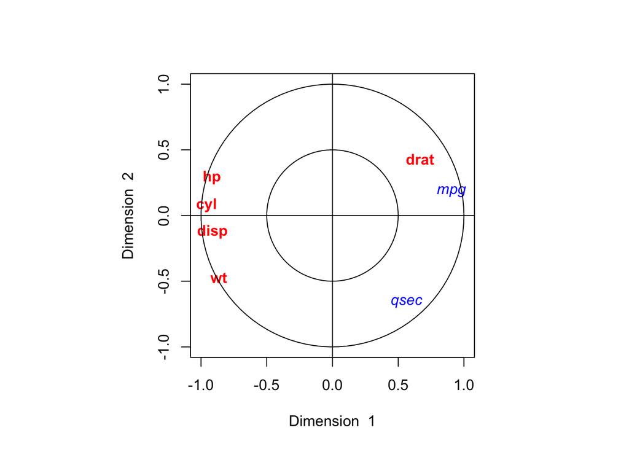

```r
plt.cc(cc.out, var.label = T, type='v')
```

Interpret the output of this canonical correlation analysis.

**Solution**

Firstly, note that the canonical correlations are high, indicating that there is a strong relationship between the car characteristics and the performance measures.

The first pair of CC scores is $\eta_1$ (the transformed characteristics variable) and $\psi_1$ (the transformed performance variable).